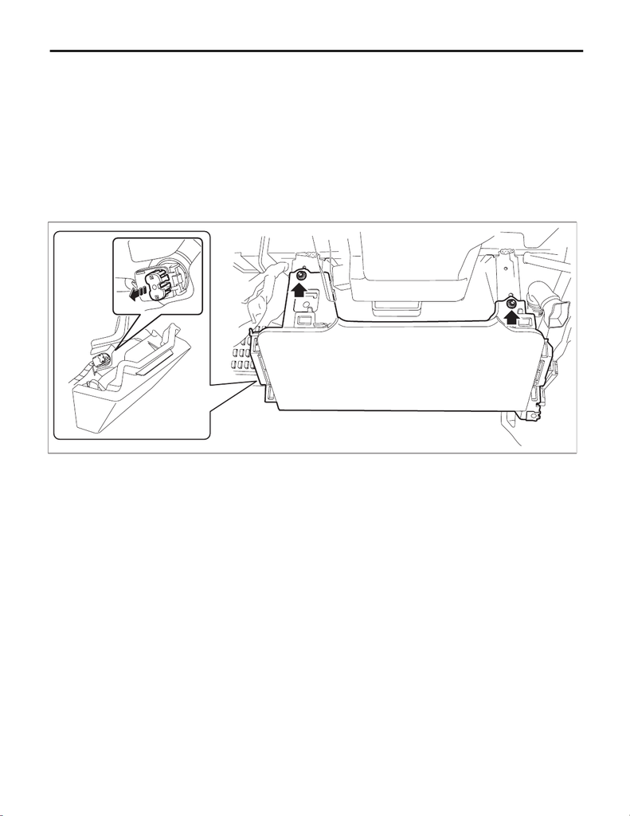

AB-35

Knee Airbag Module

AIRBAG SYSTEM

5. Knee Airbag Module

A: REMOVAL

1) Turn the ignition switch to OFF.

NOTE:

For models other than STI model, disconnect the ground terminal from battery sensor.

B: INSTALLATION

CAUTION:

• Do not allow harness and connectors to interfere or get tangled up with other parts.

1) Before installation, inspect the following items and replace any faulty part with a new one.

• Airbag module is cracked or deformed.

• Knee airbag module bracket is cracked or deformed.

• Harness and/or connector is cracked, deformed or open.

• Harness wire is exposed.

2) Install the knee airbag module.

CAUTION:

• Be sure to insert the connector in until it is locked.

• Press in the push lock securely. Then pull it gently to make sure that it is locked.

Tightening torque:

7.5 N·m (0.8 kgf-m, 5.5 ft-lb)

3) Connect the battery ground terminal. <Ref. to NT-5, BATTERY, NOTE, Note.>

NOTE:

For models other than STI model, connect the ground terminal to battery sensor.

AB-03557